# STAT_Final

```python
#import chart_studio.plotly as py
import numpy as np
import matplotlib as plt
import seaborn as sns
from scipy import stats
import scipy
from plotly.tools import FigureFactory as FF
from plotly.offline import iplot
from  plotly.offline import plot
import pandas as pd
from sklearn.model_selection import train_test_split
from sklearn import datasets, linear_model, metrics
from sklearn.metrics import mean_squared_error
from sklearn.preprocessing import StandardScaler
from sklearn.linear_model import LinearRegression
from mlxtend.feature_selection import SequentialFeatureSelector as sfs
from sklearn.linear_model import LinearRegression
from statsmodels.regression.linear_model import OLS
from statsmodels.tools import add_constant
from math import sqrt
from sklearn.ensemble import RandomForestRegressor
import warnings
warnings.filterwarnings("ignore")
from sklearn.cluster import KMeans
from sklearn.preprocessing import StandardScaler, normalize
from sklearn.decomposition import PCA
from sklearn.metrics import silhouette_score
```

#### Load the neurons group 1.csv dataset into Python as a pandas DataFrame

```python
neu_1 =  pd.read_csv('neurons_group_1.csv',index_col=0)
neu_1.head()
```

| id | average_diameter | overall_depth | overall_height | overall_width | soma_surface | total_length | total_surface | total_volume |
| --- | --- | --- | --- | --- | --- | --- | --- | --- |
| 484775243 | 0.195628 | 90.3529 | 548.798070 | 257.109717 | 128.269219 | 3658.629571 | 2252.681880 | 115.626135 |
| 485996843 | 0.457635 | 87.0383 | 717.408343 | 199.214267 | 430.635072 | 4158.819949 | 5944.196007 | 730.014704 |
| 486041253 | 0.295455 | 75.3286 | 584.083922 | 386.076695 | 502.033948 | 2667.618389 | 2472.795020 | 197.063796 |
| 491119181 | 0.414033 | 89.0718 | 284.641670 | 239.492610 | 383.828302 | 1543.941010 | 2008.838025 | 237.466517 |
| 491119245 | 0.201323 | 44.5237 | 302.038542 | 323.493562 | 120.229052 | 1621.871325 | 1027.220686 | 54.521240 |

#### (b) Inspect the data. How many neurons are included in this dataset? How many different measurements are included? Does this dataset contain any missing values?

```python
neu_1.shape
```

```
(311, 8)
```

```python
neu_1.describe()
```

|  | average_diameter | overall_depth | overall_height | overall_width | soma_surface | total_length | total_surface | total_volume |
| --- | --- | --- | --- | --- | --- | --- | --- | --- |
| count | 311.000000 | 311.000000 | 311.000000 | 311.000000 | 311.000000 | 311.000000 | 311.000000 | 311.000000 |
| mean | 0.421175 | 91.967024 | 523.516774 | 320.548089 | 361.849689 | 3792.940198 | 5492.737135 | 808.488483 |
| std | 0.159435 | 35.658760 | 299.256684 | 124.039953 | 253.912293 | 2775.993259 | 5719.713426 | 1190.466808 |
| min | 0.053899 | 22.680000 | 82.836871 | 49.173247 | 2.895610 | 251.987893 | 402.242787 | 4.309842 |
| 25% | 0.322128 | 64.574450 | 328.964661 | 233.480547 | 176.194233 | 2237.031837 | 2253.626506 | 197.071679 |
| 50% | 0.415613 | 86.212200 | 469.151885 | 291.532148 | 311.568275 | 2946.858866 | 3636.755377 | 407.180171 |
| 75% | 0.527572 | 115.566350 | 651.885452 | 392.534334 | 478.796933 | 4085.692910 | 5895.663836 | 833.681728 |
| max | 1.156730 | 183.960000 | 1928.118350 | 827.752239 | 1283.720986 | 15697.415190 | 37182.284100 | 8482.061401 |

```python
neu_1.isnull().sum()
```

```
average_diameter    0
overall_depth       0
overall_height      0
overall_width       0
soma_surface        0
total_length        0
total_surface       0
total_volume        0
dtype: int64
```

#### (d) Perform an exploratory data analysis, creating both numerical and graphical summaries of the data. Discuss and interpret your results.

```python
neu_1.dtypes
```

```
average_diameter    float64
overall_depth       float64
overall_height      float64
overall_width       float64
soma_surface        float64
total_length        float64
total_surface       float64
total_volume        float64
dtype: object
```

```python
neu_1.corr()
```

|  | average_diameter | overall_depth | overall_height | overall_width | soma_surface | total_length | total_surface | total_volume |
| --- | --- | --- | --- | --- | --- | --- | --- | --- |
| average_diameter | 1.000000 | 0.121760 | 0.284444 | 0.288901 | 0.585417 | 0.315848 | 0.604287 | 0.661577 |
| overall_depth | 0.121760 | 1.000000 | 0.520923 | 0.519506 | 0.228450 | 0.558483 | 0.453607 | 0.388688 |
| overall_height | 0.284444 | 0.520923 | 1.000000 | 0.527844 | 0.379300 | 0.704225 | 0.663516 | 0.597226 |
| overall_width | 0.288901 | 0.519506 | 0.527844 | 1.000000 | 0.408485 | 0.681586 | 0.647549 | 0.576760 |
| soma_surface | 0.585417 | 0.228450 | 0.379300 | 0.408485 | 1.000000 | 0.486353 | 0.613804 | 0.586267 |
| total_length | 0.315848 | 0.558483 | 0.704225 | 0.681586 | 0.486353 | 1.000000 | 0.911939 | 0.802144 |
| total_surface | 0.604287 | 0.453607 | 0.663516 | 0.647549 | 0.613804 | 0.911939 | 1.000000 | 0.962517 |
| total_volume | 0.661577 | 0.388688 | 0.597226 | 0.576760 | 0.586267 | 0.802144 | 0.962517 | 1.000000 |

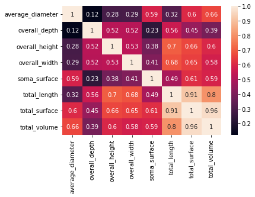

```python
sns.heatmap(neu_1.corr(),annot=True)
```

```python
neu_1.columns
```

```
Index(['average_diameter', 'overall_depth', 'overall_height', 'overall_width',
       'soma_surface', 'total_length', 'total_surface', 'total_volume'],
      dtype='object')
```

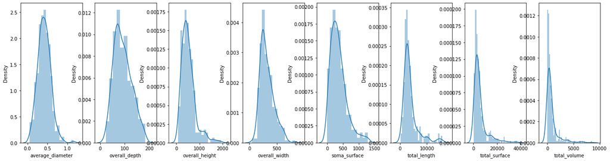

```python
column_values_1 = neu_1.columns.values
plt.figure(figsize=(25,65))
for i in range(0,len(column_values_1)):
    plt.subplot(10,9,i+1)
    sns.distplot(neu_1[column_values_1[i]],kde=True)
```

## Question 2

#### a) Load the neurons group 2.csv dataset into Python as a pandas DataFrame

```python
neu_2 = pd.read_csv('neurons_group_2.csv',index_col=0)
neu_2.head()
```

| id | average_diameter | overall_depth | overall_height | overall_width | soma_surface | total_length | total_surface | total_volume |
| --- | --- | --- | --- | --- | --- | --- | --- | --- |
| 397905347 | 0.316091 | 117.5429 | 585.602322 | 287.122628 | 268.777679 | 3498.090031 | 3523.606841 | 306.290931 |
| 491119234 | 0.331268 | 81.9012 | 461.280515 | 275.146120 | 551.788645 | 2008.302439 | 2097.688550 | 188.431435 |
| 491119269 | 0.139015 | 57.5697 | 324.422347 | 280.851229 | 50.092109 | 1774.258366 | 776.076427 | 25.733000 |
| 491119394 | 0.230412 | 76.0357 | 368.298267 | 251.377567 | 244.457685 | 1650.188964 | 1198.531518 | 75.823080 |
| 491119419 | 0.321163 | 98.8344 | 417.890620 | 193.590563 | 252.423672 | 2066.369729 | 2085.789861 | 180.446414 |

#### (b) Inspect the data. How many neurons are included in this dataset? Are the measurements the same as those in neurons group 1.csv?

```python
print(neu_1.shape,neu_2.shape)
```

```
(311, 8) (390, 8)
```

### ANS

#### For Neurons1.csv we have 311 rows and 8 columns in total For Neurons2.csv we have 390 rows and 8 columns in totals

#### As per observation we can say that the mesasurements are same for both the data as we have 8 columns for both of them but in Neurons2.csv we have 79 more rows the Neurons1.csv

#### (c) Perform a t-test, for each of the measurements, to test whether any of the neuron properties differ between the group 1 and group 2. Use a significance level of α = 0.01. Display the t-score and p-value for each measurement. Clearly state the conclusion of your tests and explain your reasoning

```python
import pprint
alpha = 0.1
t_val,p_val = stats.ttest_ind(neu_1,neu_2)
t_val,p_val
alpha = 0.01

#onesample_results = scipy.stats.ttest_1samp(data1, true_mu)
matrix_onesample = [
        ['Columns','T- Value','P-Value','alpha'],
        ['average_diameter',t_val[0],p_val[0],alpha],
        ['overall_depth',t_val[1],p_val[1],alpha],
        ['overall_height',t_val[2],p_val[2],alpha],
        ['overall_width',t_val[3],p_val[3],alpha],
        ['soma_surface',t_val[4],p_val[4],alpha],
        ['total_length',t_val[5],p_val[5],alpha],
        ['total_surface',t_val[6],p_val[6],alpha],
        ['total_volume',t_val[7],p_val[7],alpha]

    ]
pprint.pprint(matrix_onesample)
# onesample_table = FF.create_table(matrix_onesample, index=True)
# iplot(onesample_table, filename='onesample-table')
```

```
[['Columns', 'T- Value', 'P-Value', 'alpha'],
 ['average_diameter', -1.1970075781748382, 0.23170939849935634, 0.01],
 ['overall_depth', -1.1857230913955603, 0.23613458215666974, 0.01],
 ['overall_height', 0.5860348440044614, 0.5580412742530052, 0.01],
 ['overall_width', -0.9231920391791176, 0.3562256919514518, 0.01],
 ['soma_surface', -0.547797643314149, 0.5840057333717408, 0.01],
 ['total_length', -0.332599650604377, 0.7395362277560685, 0.01],
 ['total_surface', -0.8152397825540432, 0.4152127535605644, 0.01],
 ['total_volume', -0.9313735524535135, 0.35198192808008355, 0.01]]
```

## Question 3

#### a) Load the neurons additional measurements.csv into Python and combine all three datasets into a single DataFrame

```python
neu_3 = pd.read_csv('neurons_additional_measurements.csv',index_col=0)
neu_3.head()
```

| id | average_bifurcation_angle_local | average_contraction | average_fragmentation | average_parent_daughter_ratio | max_branch_order | max_euclidean_distance | max_path_distance | number_bifurcations | number_branches | number_nodes | number_stems | number_tips |
| --- | --- | --- | --- | --- | --- | --- | --- | --- | --- | --- | --- | --- |
| 491119743 | 82.727781 | 0.864267 | 20.723077 | 0.964510 | 6 | 99.779724 | 126.593790 | 33 | 73 | 1470 | 7 | 40 |
| 546781359 | 82.506680 | 0.903890 | 105.277778 | 0.862183 | 3 | 432.383110 | 496.831994 | 9 | 23 | 2011 | 5 | 14 |
| 537042261 | 77.536678 | 0.863104 | 73.666667 | 0.926633 | 6 | 373.630444 | 436.958952 | 21 | 46 | 3137 | 4 | 25 |
| 689123605 | 76.583222 | 0.900537 | 95.979167 | 0.942049 | 11 | 943.382549 | 989.448318 | 24 | 52 | 4652 | 4 | 28 |
| 657879305 | 72.019250 | 0.873518 | 47.535714 | 1.000000 | 5 | 186.218009 | 221.639502 | 14 | 32 | 1406 | 4 | 18 |

```python
neu_3.shape
```

```
(694, 12)
```

```python
concatenated = pd.concat([neu_1, neu_2], axis=0)
```

```python
dif = concatenated.index.difference(neu_3.index)
```

#### These are the ID's of neurons which are not common in both the groups

```python
dif
```

```
Int64Index([495335458, 556384323, 610886034, 653182658, 661930435, 669287805,
            841869334],
           dtype='int64', name='id')
```

```python
ful_data = pd.merge(concatenated, neu_3, left_index=True, right_index=True)
```

#### below is the side by side comparison of both data sets

```python
print( 'Fully combined dataset ',ful_data.shape, neu_3.shape)
```

```
Fully combined dataset  (694, 20) (694, 12)
```

#### Correlation is that it is used to check the relationship strength between the two variables, i.e if we change the value in one variable the correlation table will shows the level by which there will be a change in the second variable. Pearson coefficient correlation is used to measure the correlation for the linear data. The coefficient's value lie between -1 and 1. Where the value between 0 and 1 signifies positive correlation and value between -1 and 0 signifies negative correlation. Whereas, the value of 0 signifies no correlation.

```python
full_co = ful_data.corr(method='pearson')
full_co
```

|  | average_diameter | overall_depth | overall_height | overall_width | soma_surface | total_length | total_surface | total_volume | average_bifurcation_angle_local | average_contraction | average_fragmentation | average_parent_daughter_ratio | max_branch_order | max_euclidean_distance | max_path_distance | number_bifurcations | number_branches | number_nodes | number_stems | number_tips |
| --- | --- | --- | --- | --- | --- | --- | --- | --- | --- | --- | --- | --- | --- | --- | --- | --- | --- | --- | --- | --- |
| average_diameter | 1.000000 | 0.229786 | 0.327179 | 0.367010 | 0.589195 | 0.352461 | 0.619391 | 0.658883 | 0.039447 | -0.262180 | 0.353716 | 0.274922 | 0.172831 | 0.300276 | 0.313598 | 0.164862 | 0.151537 | 0.345626 | -0.131749 | 0.138467 |
| overall_depth | 0.229786 | 1.000000 | 0.527627 | 0.515622 | 0.238661 | 0.566376 | 0.482570 | 0.405527 | -0.067234 | -0.168192 | 0.420348 | 0.004063 | 0.496938 | 0.542190 | 0.581248 | 0.434871 | 0.434845 | 0.552837 | 0.166980 | 0.433055 |
| overall_height | 0.327179 | 0.527627 | 1.000000 | 0.472310 | 0.306192 | 0.660042 | 0.618149 | 0.540829 | -0.170636 | -0.011630 | 0.546112 | -0.057364 | 0.614627 | 0.954598 | 0.941420 | 0.432410 | 0.425560 | 0.655673 | 0.066929 | 0.417486 |
| overall_width | 0.367010 | 0.515622 | 0.472310 | 1.000000 | 0.400587 | 0.680065 | 0.660372 | 0.579829 | -0.088734 | -0.070939 | 0.655019 | 0.107348 | 0.269896 | 0.482814 | 0.502016 | 0.370920 | 0.365143 | 0.673310 | 0.061535 | 0.358484 |
| soma_surface | 0.589195 | 0.238661 | 0.306192 | 0.400587 | 1.000000 | 0.428615 | 0.549134 | 0.537021 | -0.062920 | -0.049990 | 0.330257 | 0.109646 | 0.155667 | 0.263454 | 0.265640 | 0.266762 | 0.263538 | 0.428377 | 0.055295 | 0.259445 |
| total_length | 0.352461 | 0.566376 | 0.660042 | 0.680065 | 0.428615 | 1.000000 | 0.913416 | 0.790274 | -0.143934 | -0.064172 | 0.456874 | 0.102789 | 0.599113 | 0.641754 | 0.654762 | 0.817617 | 0.811752 | 0.998333 | 0.234539 | 0.803354 |
| total_surface | 0.619391 | 0.482570 | 0.618149 | 0.660372 | 0.549134 | 0.913416 | 1.000000 | 0.958704 | -0.124021 | -0.136860 | 0.474200 | 0.183065 | 0.495238 | 0.597350 | 0.608415 | 0.684764 | 0.674198 | 0.909903 | 0.113077 | 0.661868 |
| total_volume | 0.658883 | 0.405527 | 0.540829 | 0.579829 | 0.537021 | 0.790274 | 0.958704 | 1.000000 | -0.113610 | -0.168131 | 0.436098 | 0.181217 | 0.401908 | 0.520168 | 0.531298 | 0.561337 | 0.550372 | 0.787010 | 0.058827 | 0.538113 |
| average_bifurcation_angle_local | 0.039447 | -0.067234 | -0.170636 | -0.088734 | -0.062920 | -0.143934 | -0.124021 | -0.113610 | 1.000000 | -0.256651 | -0.033428 | 0.144248 | -0.057797 | -0.160161 | -0.138639 | -0.104305 | -0.107519 | -0.139077 | -0.088756 | -0.110187 |
| average_contraction | -0.262180 | -0.168192 | -0.011630 | -0.070939 | -0.049990 | -0.064172 | -0.136860 | -0.168131 | -0.256651 | 1.000000 | -0.232868 | -0.196380 | -0.055551 | -0.038668 | -0.095109 | 0.054079 | 0.059078 | -0.067872 | 0.093060 | 0.063447 |
| average_fragmentation | 0.353716 | 0.420348 | 0.546112 | 0.655019 | 0.330257 | 0.456874 | 0.474200 | 0.436098 | -0.033428 | -0.232868 | 1.000000 | 0.133164 | 0.041575 | 0.463791 | 0.469273 | -0.030394 | -0.037248 | 0.457285 | -0.111443 | -0.043461 |
| average_parent_daughter_ratio | 0.274922 | 0.004063 | -0.057364 | 0.107348 | 0.109646 | 0.102789 | 0.183065 | 0.181217 | 0.144248 | -0.196380 | 0.133164 | 1.000000 | -0.136795 | -0.114534 | -0.108647 | 0.010898 | -0.004622 | 0.099655 | -0.222174 | -0.019046 |
| max_branch_order | 0.172831 | 0.496938 | 0.614627 | 0.269896 | 0.155667 | 0.599113 | 0.495238 | 0.401908 | -0.057797 | -0.055551 | 0.041575 | -0.136795 | 1.000000 | 0.678247 | 0.706142 | 0.712654 | 0.713865 | 0.598367 | 0.295542 | 0.712331 |
| max_euclidean_distance | 0.300276 | 0.542190 | 0.954598 | 0.482814 | 0.263454 | 0.641754 | 0.597350 | 0.520168 | -0.160161 | -0.038668 | 0.463791 | -0.114534 | 0.678247 | 1.000000 | 0.989598 | 0.458671 | 0.456456 | 0.638202 | 0.145440 | 0.452622 |
| max_path_distance | 0.313598 | 0.581248 | 0.941420 | 0.502016 | 0.265640 | 0.654762 | 0.608415 | 0.531298 | -0.138639 | -0.095109 | 0.469273 | -0.108647 | 0.706142 | 0.989598 | 1.000000 | 0.477001 | 0.474840 | 0.650522 | 0.153536 | 0.470999 |
| number_bifurcations | 0.164862 | 0.434871 | 0.432410 | 0.370920 | 0.266762 | 0.817617 | 0.684764 | 0.561337 | -0.104305 | 0.054079 | -0.030394 | 0.010898 | 0.712654 | 0.458671 | 0.477001 | 1.000000 | 0.997993 | 0.818667 | 0.361552 | 0.992465 |
| number_branches | 0.151537 | 0.434845 | 0.425560 | 0.365143 | 0.263538 | 0.811752 | 0.674198 | 0.550372 | -0.107519 | 0.059078 | -0.037248 | -0.004622 | 0.713865 | 0.456456 | 0.474840 | 0.997993 | 1.000000 | 0.812985 | 0.419783 | 0.998230 |
| number_nodes | 0.345626 | 0.552837 | 0.655673 | 0.673310 | 0.428377 | 0.998333 | 0.909903 | 0.787010 | -0.139077 | -0.067872 | 0.457285 | 0.099655 | 0.598367 | 0.638202 | 0.650522 | 0.818667 | 0.812985 | 1.000000 | 0.237684 | 0.804757 |
| number_stems | -0.131749 | 0.166980 | 0.066929 | 0.061535 | 0.055295 | 0.234539 | 0.113077 | 0.058827 | -0.088756 | 0.093060 | -0.111443 | -0.222174 | 0.295542 | 0.145440 | 0.153536 | 0.361552 | 0.419783 | 0.237684 | 1.000000 | 0.473023 |
| number_tips | 0.138467 | 0.433055 | 0.417486 | 0.358484 | 0.259445 | 0.803354 | 0.661868 | 0.538113 | -0.110187 | 0.063447 | -0.043461 | -0.019046 | 0.712331 | 0.452622 | 0.470999 | 0.992465 | 0.998230 | 0.804757 | 0.473023 | 1.000000 |

#### this is to get the highest corelation whule removing the dublicate cor relation which one other

```python
high_co = full_co.unstack().sort_values()

print(high_co)
```

```
average_contraction              average_diameter                  -0.262180
average_diameter                 average_contraction               -0.262180
average_bifurcation_angle_local  average_contraction               -0.256651
average_contraction              average_bifurcation_angle_local   -0.256651
average_fragmentation            average_contraction               -0.232868
                                                                      ...
max_path_distance                max_path_distance                  1.000000
number_bifurcations              number_bifurcations                1.000000
number_branches                  number_branches                    1.000000
average_contraction              average_contraction                1.000000
number_tips                      number_tips                        1.000000
Length: 400, dtype: float64
```

```python
upper_corr_mat = full_co.where(
    np.triu(np.ones(full_co.shape), k=1).astype(np.bool))

# removing dubplicates
unique_corr_pairs = upper_corr_mat.unstack().dropna()

sorted_mat = unique_corr_pairs.sort_values()
pairs = sorted_mat.tail(10)
print(pairs)
```

```
number_nodes            total_surface             0.909903
total_surface           total_length              0.913416
max_path_distance       overall_height            0.941420
max_euclidean_distance  overall_height            0.954598
total_volume            total_surface             0.958704
max_path_distance       max_euclidean_distance    0.989598
number_tips             number_bifurcations       0.992465
number_branches         number_bifurcations       0.997993
number_tips             number_branches           0.998230
number_nodes            total_length              0.998333
dtype: float64
```

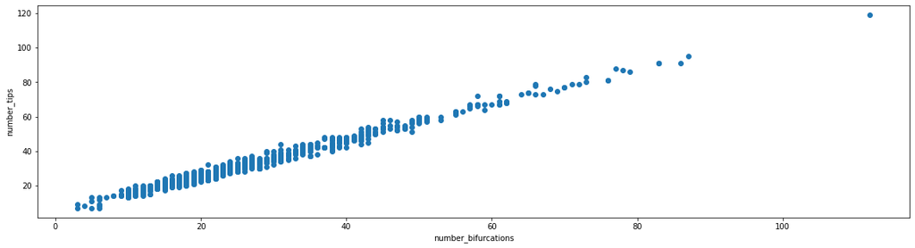

```python
import matplotlib.pyplot as plt
plt.figure(figsize=(20,5))
plt.xlabel("number_bifurcations")
plt.ylabel("number_tips")
plt.scatter(ful_data['number_bifurcations'], ful_data['number_tips'])
plt.show()
```

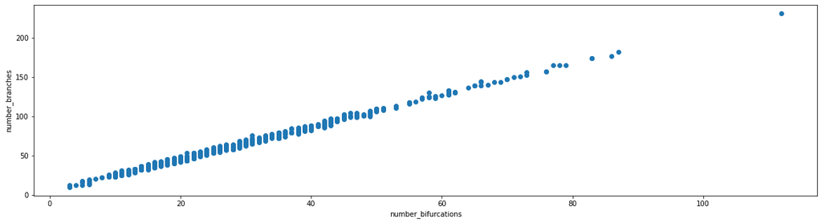

```python
plt.figure(figsize=(20,5))
plt.xlabel("number_bifurcations")
plt.ylabel("number_branches")
plt.scatter(ful_data['number_bifurcations'], ful_data['number_branches'])
plt.show()
```

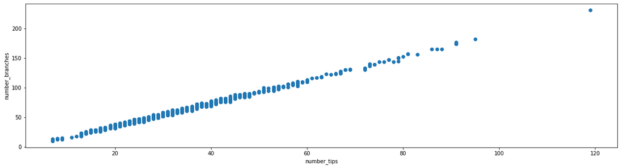

```python
plt.figure(figsize=(20,5))
plt.xlabel("number_tips")
plt.ylabel("number_branches")
plt.scatter(ful_data['number_tips'],ful_data['number_branches'])
plt.show()
```

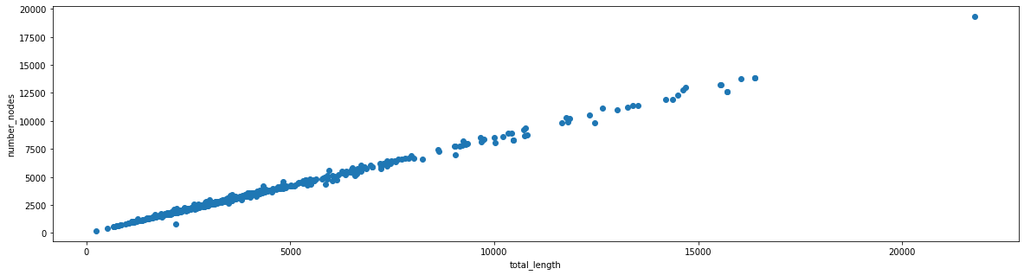

```python
plt.figure(figsize=(20,5))
plt.xlabel("total_length")
plt.ylabel("number_nodes")
plt.scatter(ful_data['total_length'], ful_data['number_nodes'])
plt.show()
```

[figure not shown]

```python
import matplotlib.pyplot as plt

df=  pairs.to_frame()
df.reset_index(inplace=True)
df['x_axis'] = df['level_0'] + df['level_1']
df.drop(['level_0','level_1'],axis=1)
plt.figure(figsize=(8, 8),dpi=800)
df.plot(kind='scatter',x='x_axis',y=0)
plt.xticks(fontsize = 10)
plt.show()
```